# Posterior

Linyi Guo

2019/11/6

Well, time to program now. Maybe let me finish my lunch at first :)

# Introduction

We will use the data from statcan this time and also use 10 different datasets perhaps. These datasets are denoted as data1, data2, …

# X11 models & Results

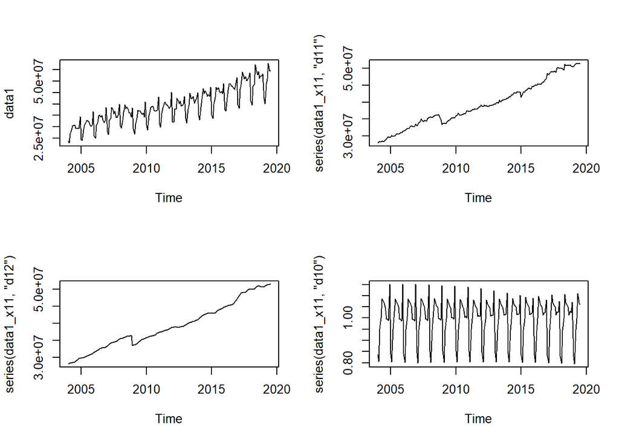

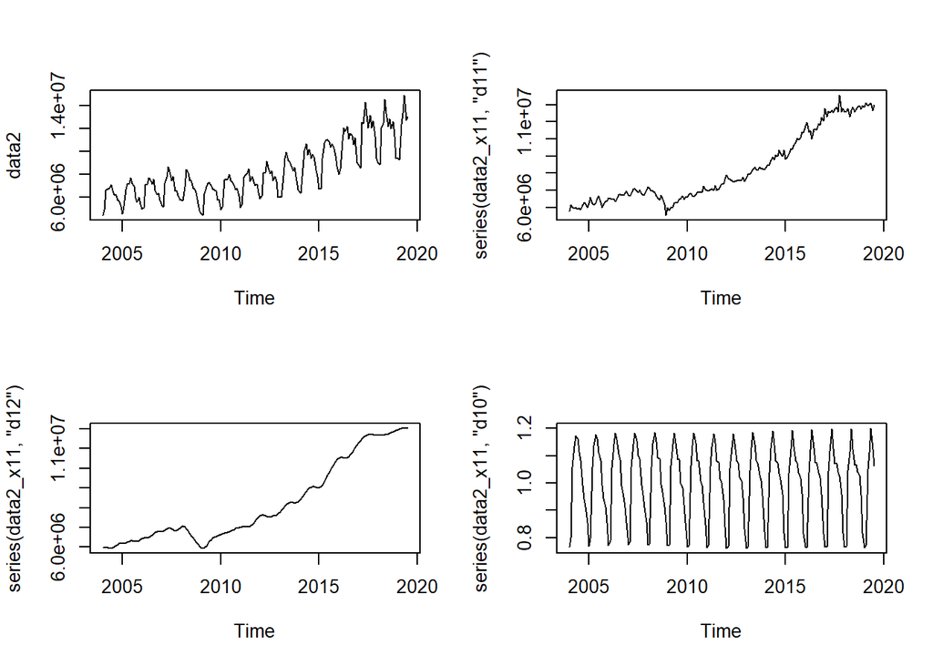

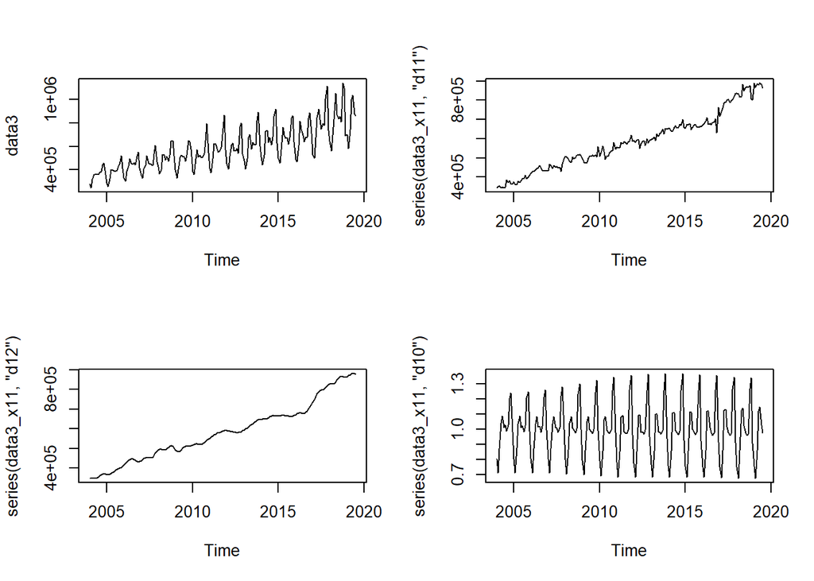

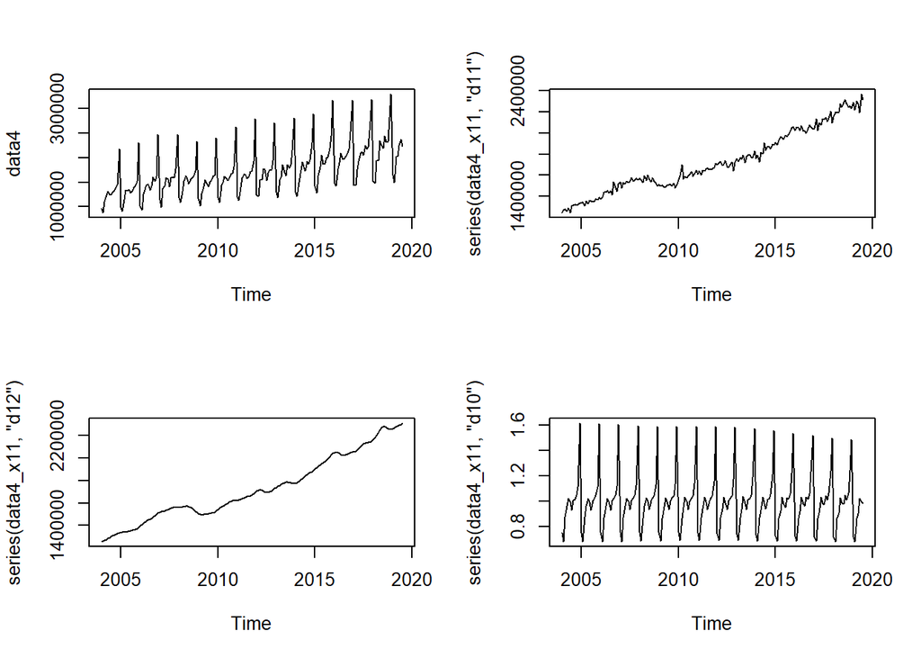

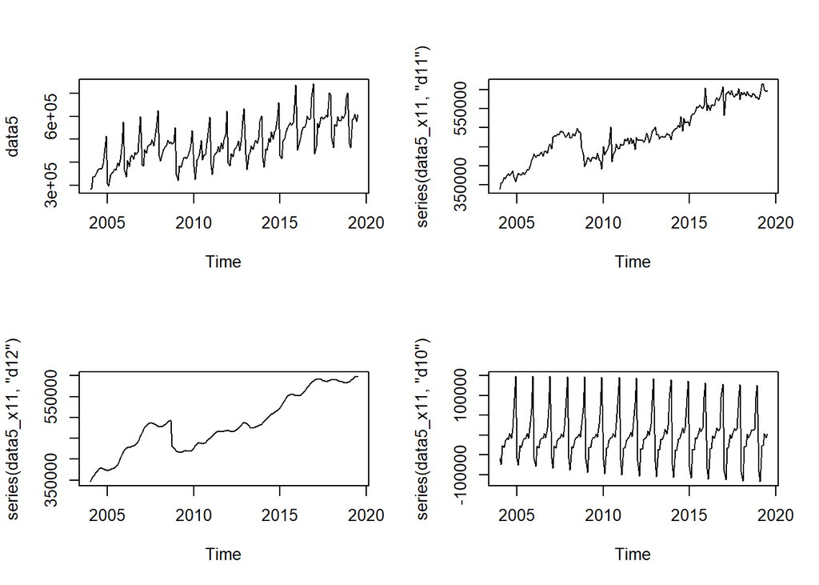

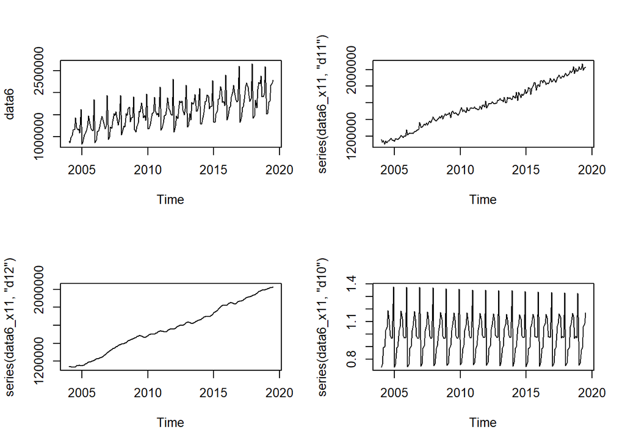

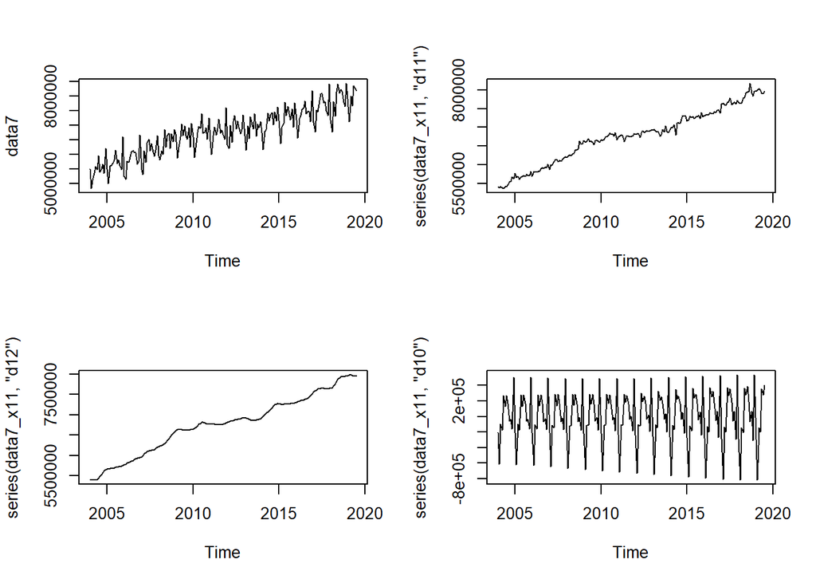

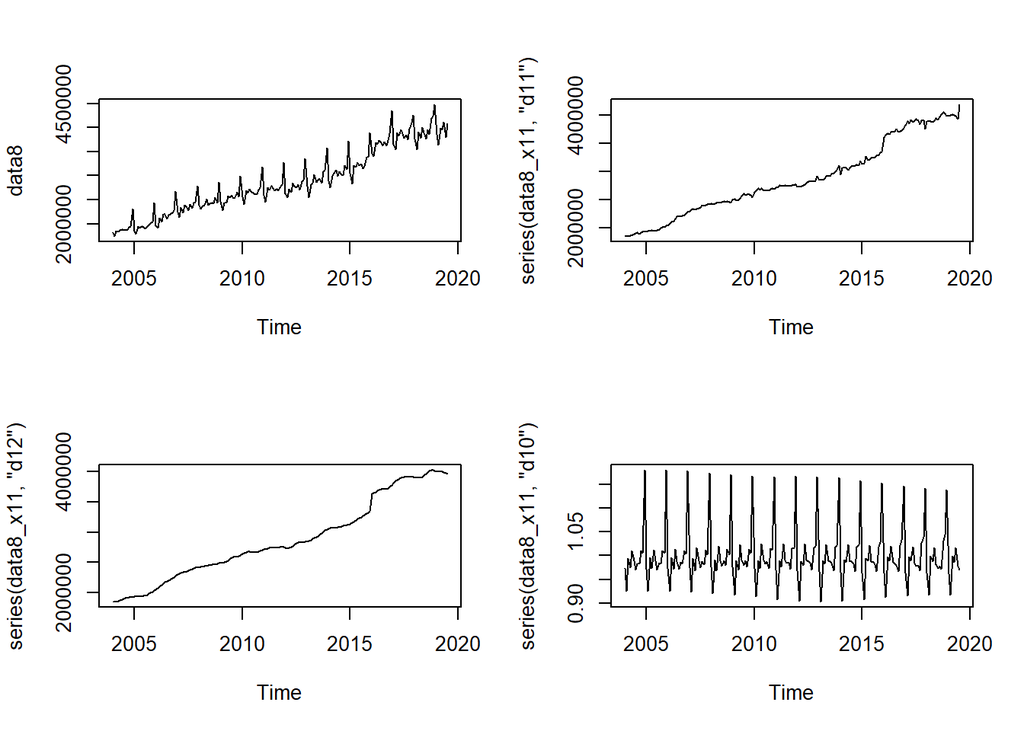

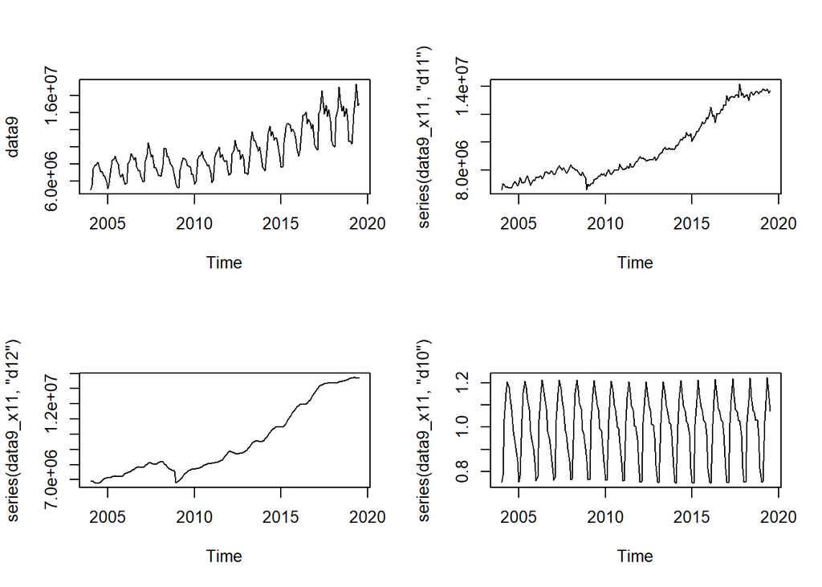

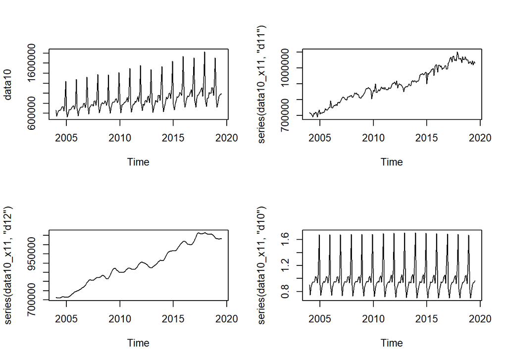

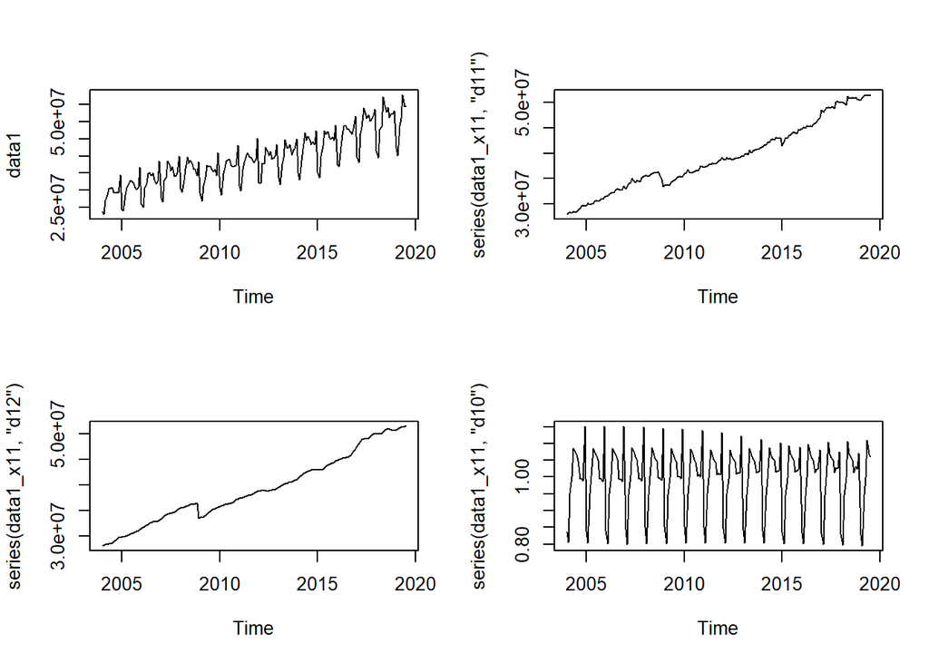

```r
data1_ssmm <- SSModel(log(data1) ~ SSMtrend(1, Q=list(1)) +
                   SSMseasonal(12, sea.type = 'dummy', Q = 1),
                 H = 1)
data1_ssm <- KFS(data1_ssmm)


data1_ssm_trend <- coef(data1_ssm, states = 'trend')
data1_ssm_seasonal <- -rowSums(coef(data1_ssm, states='seasonal'))
data1_ssm_irregular <- data1[-1] - data1_ssm_trend[-1] - data1_ssm_seasonal[-length(data1)]


par(mfrow=c(2,2))
plot(data1)
plot(series(data1_x11, 'd11'))
plot(series(data1_x11, 'd12'))
plot(series(data1_x11, 'd10'))
```

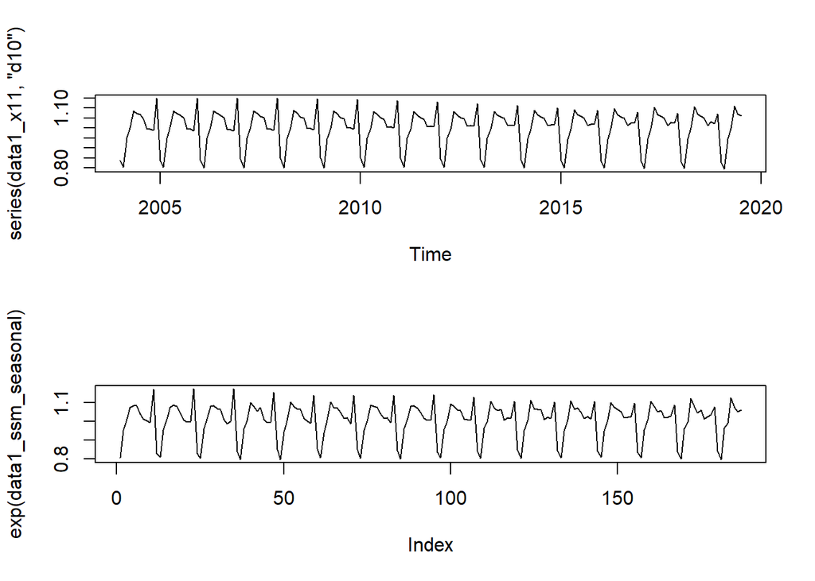

```r
par(mfrow=c(2,1))
plot(series(data1_x11, 'd10'))

plot(exp(data1_ssm_seasonal),type='l')
```

```r
par(mfrow=c(1,1))
```

# loss function

$$Loss=\frac{\sum(X11_{irregular}-SSM_{irregular})^2}{\sigma_I^2} + \frac{\sum(X11_{trend}-SSM_{trend})^2}{\sigma_T^2} + \frac{\sum(X11_{seasonal}-SSM_{seasonal})^2}{\sigma_S^2}$$

```r
# Dif1 is for normal cases, where we don't need to take log
Dif1 <- function(x11, ssm, data, sigma){

  x11_trend <- series(x11, 'd12')
  x11_seasonal <- series(x11, 'd10')
  x11_irregular <- series(x11, 'd13')

  ssm_trend <- coef(ssm, states = 'trend')
  ssm_seasonal <- -rowSums(coef(ssm, states='seasonal'))
  ssm_irregular <- data[-1] - ssm_trend[-1] - ssm_seasonal[-length(data)]

  D <-  sum((x11_irregular[-1]-ssm_irregular)^2)/sigma[1] +
    sum((x11_trend-ssm_trend)^2)/sigma[2] +
    sum((x11_seasonal[-1]-ssm_seasonal[-length(data)])^2)/sigma[3]

  return(D)
}

# if we need to transform(take log) the original data, use Dif2
Dif2 <- function(x11, ssm, data, sigma){

  x11_trend <- series(x11, 'd12')
  x11_seasonal <- series(x11, 'd10')
  x11_irregular <- series(x11, 'd13')

  ssm_trend <- exp(coef(ssm, states = 'trend'))
  ssm_seasonal <- exp(-rowSums(coef(ssm, states='seasonal')))
  ssm_irregular <- data[-1]/(ssm_trend[-1]*ssm_seasonal[-length(data)])

  D <-  sum((x11_irregular[-1]-ssm_irregular)^2)/sigma[1] +
    sum((x11_trend-ssm_trend)^2)/sigma[2] +
    sum((x11_seasonal[-1]-ssm_seasonal[-length(data)])^2)/sigma[3]

  return(D)
}
```

# logLikelihood

Because of the seasonal component, we can’t compute the likelihood of first 11 points:
$$logLikelihood = -\frac{n-11}{2}log(\sigma_y^2)-\frac{n-11}{2}log(\sigma_T^2)-\frac{n-11}{2}log(\sigma_S^2)-\frac{\sum_{i=12}^{n}(y_i-T_i-S_i)^2}{2\sigma_y^2}-\frac{\sum_{i=12}^{n}(T_i-T_{i-1})^2}{2\sigma_T^2}-\frac{\sum_{i=12}^{n}(\sum_{j=0}^{11}S_{i-j})^2}{2\sigma_S^2}$$

**Note:** in our problem we will set $\sigma_S^2=1$.

```r
loglikelihood <- function(data, trend, season, sigma){

  n <- length(data)
  a <- 0
  for (i in 12:n)  a <- a + (sum(season[(i-11):i]))^2
  l <- -(n-11)/2 * log(sigma[1]) -
    (n-11)/2 * log(sigma[2]) - (n-11)/2 * log(sigma[3]) -
    sum((data[-c(1:11)]-trend[-c(1:11)]-season[-c(1:10,n)])^2)/(2*sigma[1]) -
    sum((trend[-c(1:11)]-trend[-c(1:10,n)])^2)/(2*sigma[2]) -
    a / (2*sigma[3])
  return(l)

}
```

# logPrior

We will use imporper priors at first(we will fix this in the future).

## Prior 1: exponential

If our prior is exponential, suppose:
$$Prior(\sigma_y^2) = exp(-c1*\sigma_y^2)$$
$$Prior(\sigma_T^2) = exp(-c2*\sigma_T^2)$$
then,
$$logPrior(\sigma_y^2)= -c1*\sigma_y^2$$
$$logPrior(\sigma_T^2)= -c2*\sigma_T^2$$

Since both variances are independent, our prior is the product of them, thus our logprior is the sum of them:
$$logPrior=-c1*\sigma_y^2-c2*\sigma_T^2$$

```r
logprior1 <- function(sigma,c1,c2){
  return(-c1*sigma[1]- c2*sigma[2])
}
```

# MAP

Based on the functions defined above, given c1 and c2, our maximum a posteriori estimate is defined as:
$$MAP=\underset{\sigma_y^2, \sigma_T^2}{\arg\max}(logLikelihood+logPrior)$$

```r
logposterior_matrix <- function(data, c1, c2){
  LP <- c()
  index <- c()
   for (i in 1:100) {
     for (j in 1:100) {

         ssmm <- SSModel(data ~ SSMtrend(1, Q=list(j)) +
                   SSMseasonal(12, sea.type = 'dummy', Q = 1),
                 H = i)
         ssm <- KFS(ssmm)

         ssm_trend <- coef(ssm, states = 'trend')
         ssm_seasonal <- -rowSums(coef(ssm, states='seasonal'))
  #      ssm_seasadj <- data[-1] - ssm_seasonal[-length(data)] # length is shorter
         sigma <- c(i, j, 1)

         lp <- loglikelihood(data, ssm_trend, ssm_seasonal, sigma) + logprior1(sigma, c1, c2)
         LP <- c(LP, lp)
         index <- rbind(index, sigma)

      }
   }
  df <- data.frame(variance=index, logposterior=LP)
  return(df)
}
```

```r
data5_postmatrix <- logposterior_matrix(data5, 10^6, 10^6)
data5_postmatrix[which.max(data5_postmatrix$logposterior),]
```

```
##            variance.1 variance.2 variance.3 logposterior
## sigma.9950        100         51          1   -320251038
```

```r
logposterior_matrix <- function(data, c1, c2){
  LP <- c()
  index <- c()
   for (i in 1:100) {
     for (j in 1:100) {

         ssmm <- SSModel(data ~ SSMtrend(1, Q=list(j*.1)) +
                   SSMseasonal(12, sea.type = 'dummy', Q = 1),
                 H = i*.1)
         ssm <- KFS(ssmm)

         ssm_trend <- coef(ssm, states = 'trend')
         ssm_seasonal <- -rowSums(coef(ssm, states='seasonal'))
  #      ssm_seasadj <- data[-1] - ssm_seasonal[-length(data)] # length is shorter
         sigma <- c(i*.1, j*.1, 1)

         lp <- loglikelihood(data, ssm_trend, ssm_seasonal, sigma) + logprior1(sigma, c1, c2)
         LP <- c(LP, lp)
         index <- rbind(index, sigma)

      }
   }
  df <- data.frame(variance=index, logposterior=LP)
  return(df)
}
```

```r
data1_postmatrix <- logposterior_matrix(log(data1), 1,1)
data1_postmatrix[which.max(data1_postmatrix$logposterior),]
```

```
##       variance.1 variance.2 variance.3 logposterior
## sigma        0.1        0.1          1     404.8898
```

**PROBLEM!** for dataset *unemp*, we noticed that the loglikelihood and logposteriori are maximized when the variance takes the greatest value but now it is completely opposite! As for the reason, it is from the log-transformation here. By taking log, our data becomes much smaller, which makes the components much smaller at the same time. According to the defination of log likelihood, it is reasonable that the smaller our variances are, the larger our loglikelihood will be.

Therefore, our loglikelihood surface is different in both cases.

I want to try the exhaustion part before continuing with the log problem.

# Exhaustion

```r
# define the exhaustion function for normal(addictive) cases

exhaustion1 <- function(data){

  Difference <- c()
  index <- c()

  x11 <- seas(data, x11='')
   for (i in 1:50) {
     for (j in 1:50) {

           ssmm <- SSModel(data ~ SSMtrend(1, Q=list(j)) +
                     SSMseasonal(12, sea.type = 'dummy', Q = 1),
                   H = i)
           ssm <- KFS(ssmm)

           sigma <- c(i, j, 1)

           dif <- Dif1(x11, ssm, data, sigma)

           Difference <- c(Difference, dif)

           index <- rbind(index, sigma)
      }
   }

  df <- data.frame(variance=index, difference = Difference)
  return(df)
}
```

```r
# exhaustion function for multiplicative cases

exhaustion2 <- function(data){

  Difference <- c()
  index <- c()

  x11 <- seas(data, x11='')
   for (i in 1:50) {
     for (j in 1:50) {

           ssmm <- SSModel(log(data) ~ SSMtrend(1, Q=list(j*0.02)) +
                     SSMseasonal(12, sea.type = 'dummy', Q = 1),
                   H = i*0.02)
           ssm <- KFS(ssmm)

           sigma <- c(i*0.02, j*0.02, 1)

           dif <- Dif2(x11, ssm, data, sigma)

           Difference <- c(Difference, dif)

           index <- rbind(index, sigma)
      }
   }

  df <- data.frame(variance=index, difference = Difference)
  return(df)
}
```

**Do a little summary here2019.11.13. 1:33 am**

嗯,直接用汉字吧,就当是写个小日志了.Research的东西拖到了周二才算是真正开始做吧,然后发现做不完.这次是实在做不完,只有给Aaron发邮件申请delay,虽然这不是我的本意.因为想着之前也看了看,今天整理一下思路就可以码code了,然并卵.以后还是要把各种事情往前提啊兄弟.总结一下遇到的问题吧:

blablabla…任重而道远,keep moving!

OK, F**K. My state is so bad. It seems that I think this prolem is too easy at first. Just be patient, please. This is research! You need to do it step by step! OK? Keep working, figure out the small problem one by one and then you will achieve the purpose! OK?

```r
data1_exhaustion <- exhaustion2(data1)
data1_exhaustion[which.min(data1_exhaustion$difference),]
```

```
##            variance.1 variance.2 variance.3   difference
## sigma.2499          1          1          1 1.755207e+13
```

```r
data2_exhaustion <- exhaustion2(data2)
data2_exhaustion[which.min(data2_exhaustion$difference),]
```

```
##            variance.1 variance.2 variance.3   difference
## sigma.2499          1          1          1 1.791186e+12
```

```r
data3_exhaustion <- exhaustion2(data3)
data3_exhaustion[which.min(data3_exhaustion$difference),]
```

```
##            variance.1 variance.2 variance.3  difference
## sigma.2499          1          1          1 27144791843
```

```r
data4_exhaustion <- exhaustion2(data4)
data4_exhaustion[which.min(data4_exhaustion$difference),]
```

```
##            variance.1 variance.2 variance.3   difference
## sigma.2499          1          1          1 285587139709
```

```r
data5_exhaustion <- exhaustion1(data5)
data5_exhaustion[which.min(data5_exhaustion$difference),]
```

```
##            variance.1 variance.2 variance.3 difference
## sigma.1109         23         10          1 9454906416
```

```r
data6_exhaustion <- exhaustion2(data6)
data6_exhaustion[which.min(data6_exhaustion$difference),]
```

```
##            variance.1 variance.2 variance.3  difference
## sigma.2499          1          1          1 94395364695
```

```r
data7_exhaustion <- exhaustion1(data7)
data7_exhaustion[which.min(data7_exhaustion$difference),]
```

```
##            variance.1 variance.2 variance.3   difference
## sigma.2499         50         50          1 419959924988
```

```r
data8_exhaustion <- exhaustion2(data8)
data8_exhaustion[which.min(data8_exhaustion$difference),]
```

```
##            variance.1 variance.2 variance.3  difference
## sigma.2499          1          1          1 54347094841
```

```r
data9_exhaustion <- exhaustion2(data9)
data9_exhaustion[which.min(data9_exhaustion$difference),]
```

```
##            variance.1 variance.2 variance.3  difference
## sigma.2499          1          1          1 3.15431e+12
```

```r
data10_exhaustion <- exhaustion2(data10)
data10_exhaustion[which.min(data10_exhaustion$difference),]
```

```
##            variance.1 variance.2 variance.3  difference
## sigma.2499          1          1          1 88487728443
```

The REASON for the former case is the data 7 is too large so based on our loss function definition, to some extent the choice of variances itself plays an important role in our loss.

**我认为Aaron建议的loss function是不合适的！**

For data7, the loss is 4.1996*10^11 for c(50,50,1); 3.7595 for c(100,100,1). This result reflects that the difference of components is larger when changing c(50,50,1) to c(100,100,1) cause the ratior is not 2:1.

看看两种情况下的差别大不大：

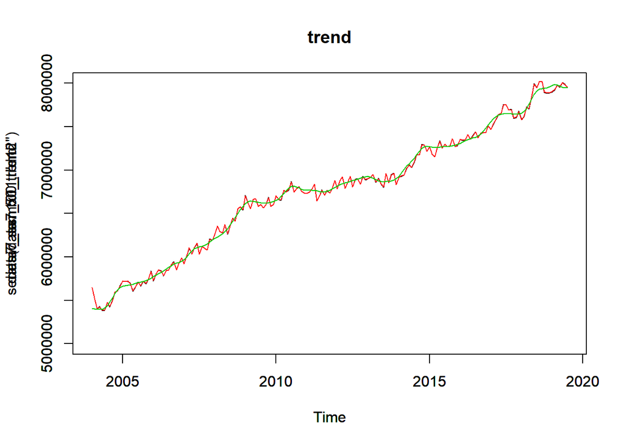

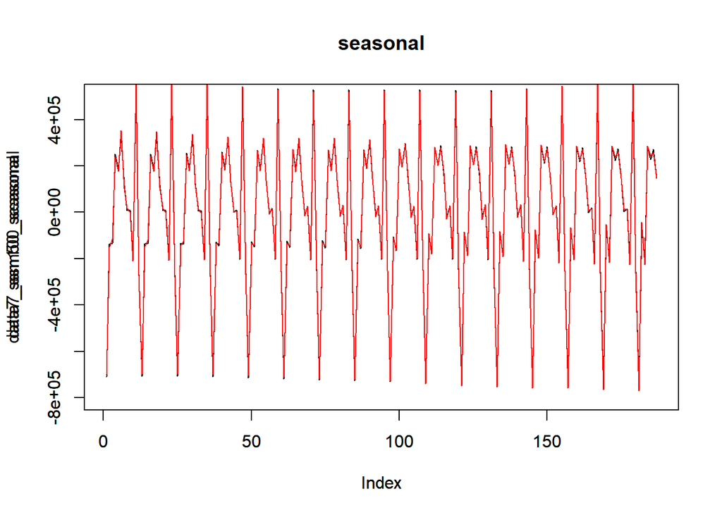

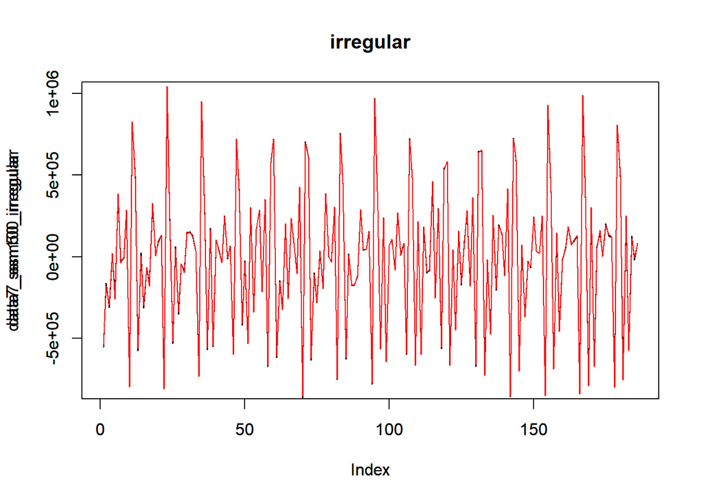

另外一个问题：这个trend不对啊！！！怎么就这么多褶子了！！！我要的平滑呢？？？这和tramo的结果出入也太大了！！！

卒。

下面的是221 441的结果：

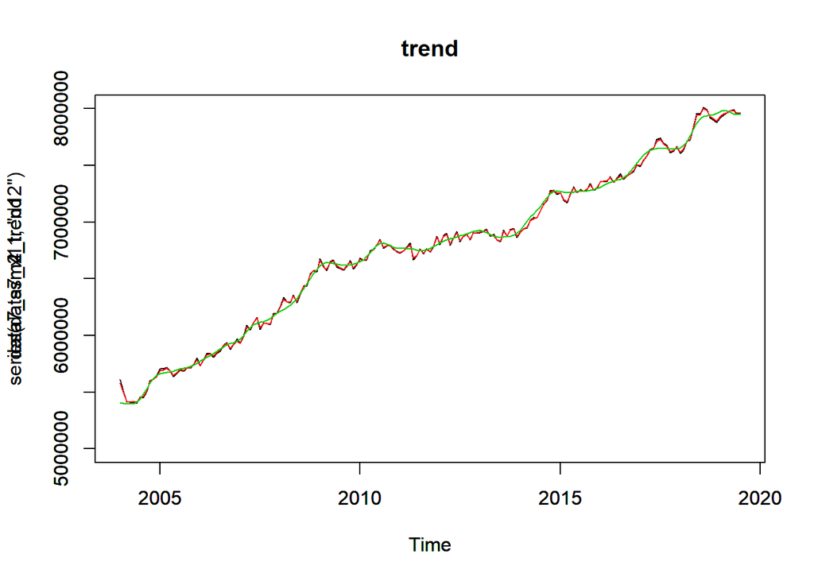

```r
data7_ssmm2 <- SSModel(data7 ~ SSMtrend(1, Q=list(2)) +
                     SSMseasonal(12, sea.type = 'dummy', Q = 1),
                   H = 2)
data7_ssm2 <- KFS(data7_ssmm2)

data7_ssmm4 <- SSModel(data7 ~ SSMtrend(1, Q=list(4)) +
                     SSMseasonal(12, sea.type = 'dummy', Q = 1),
                   H = 4)
data7_ssm4 <- KFS(data7_ssmm4)


data7_ssm2_trend <- coef(data7_ssm2, states = 'trend')
data7_ssm2_seasonal <- -rowSums(coef(data7_ssm2, states='seasonal'))
data7_ssm2_irregular <- data7[-1] - data7_ssm2_trend[-1] - data7_ssm2_seasonal[-length(data)]

data7_ssm4_trend <- coef(data7_ssm4, states = 'trend')
data7_ssm4_seasonal <- -rowSums(coef(data7_ssm4, states='seasonal'))
data7_ssm4_irregular <- data7[-1] - data7_ssm4_trend[-1] - data7_ssm4_seasonal[-length(data)]



plot(data7_ssm4_trend,ylim=c(5*10^6,8*10^6))
par(new=TRUE)
plot(data7_ssm2_trend,ylim=c(5*10^6,8*10^6),col=2)
par(new=TRUE)
plot(series(data7_x11, 'd12'),ylim=c(5*10^6,8*10^6),col=3)
title('trend')
```

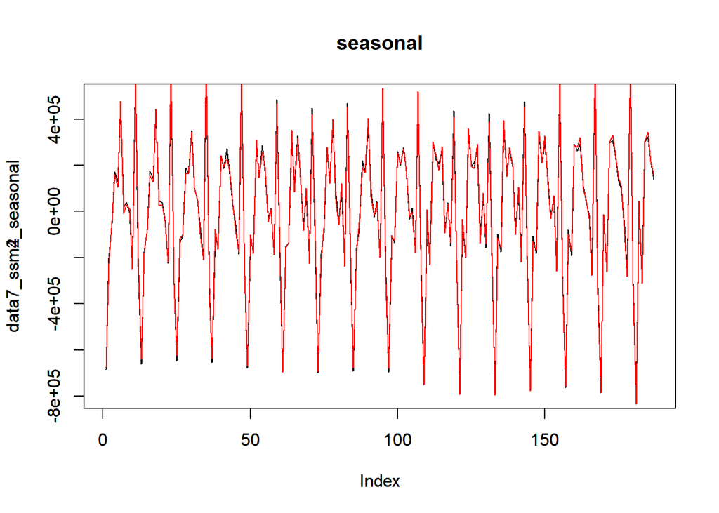

```r
plot(data7_ssm4_seasonal,type='l',ylim=c(-8*10^5, 5*10^5))
par(new=TRUE)
plot(data7_ssm2_seasonal,type='l',ylim=c(-8*10^5, 5*10^5),col=2)
title('seasonal')
```

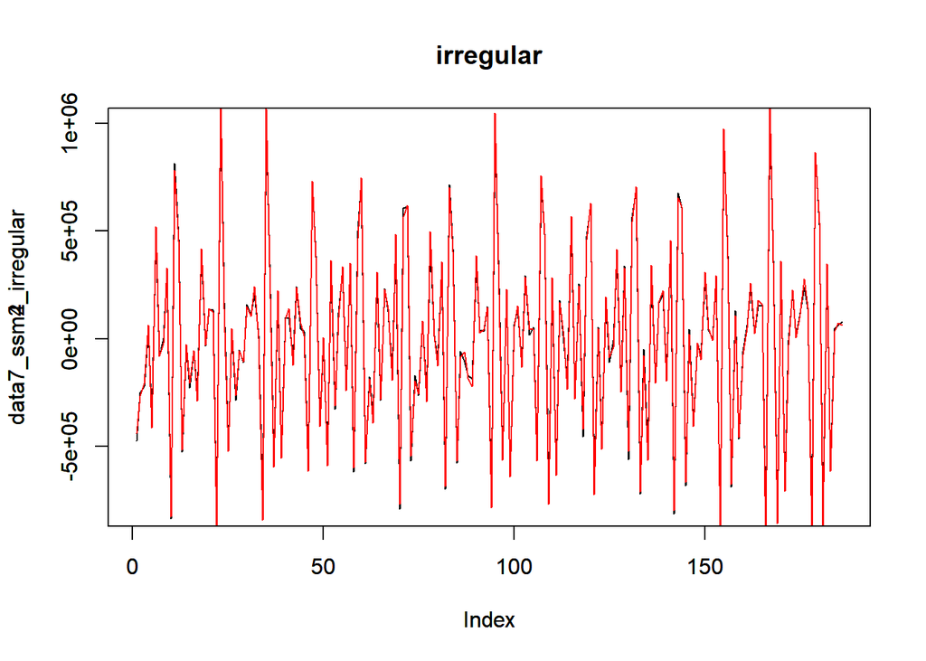

```r
plot(data7_ssm4_irregular,type='l',ylim=c(-8*10^5, 10^6))
par(new=TRUE)
plot(data7_ssm2_irregular,type='l',ylim=c(-8*10^5, 10^6),col=2)
title('irregular')
```

这个是为了看看trend能不能平滑一点：

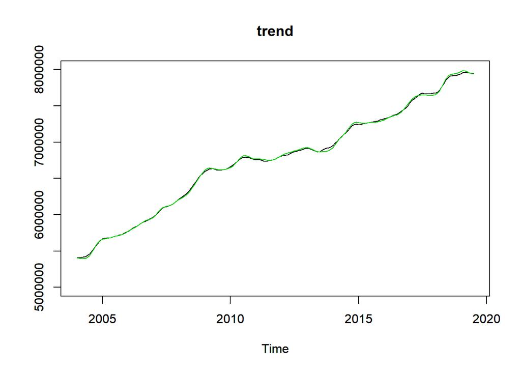

```r
data7_ssmm1 <- SSModel(series(data7_x11,'b1') ~ SSMtrend(1, Q=list(0.3)) +
                     SSMseasonal(12, sea.type = 'dummy', Q = 1),
                   H = 1)
data7_ssm1 <- KFS(data7_ssmm1)


data7_ssm1_trend <- coef(data7_ssm1, states = 'trend')
data7_ssm1_seasonal <- -rowSums(coef(data7_ssm1, states='seasonal'))
data7_ssm1_irregular <- data7[-1] - data7_ssm1_trend[-1] - data7_ssm1_seasonal[-length(data)]


plot(data7_ssm1_trend,ylim=c(5*10^6,8*10^6),ylab='')
par(new=TRUE)
plot(series(data7_x11, 'd12'),ylim=c(5*10^6,8*10^6),ylab='',col=3)
title('trend')
```

After using the preprocessing argument ‘b1’, our results look better!!!!! which is good !!!

let’s see whether the same thing could happen on 50501 and 1001001.(**Notice: we will cover the model we defined before!**)

```r
data7_ssmm50 <- SSModel(series(data7_x11,'b1') ~ SSMtrend(1, Q=list(50)) +
                     SSMseasonal(12, sea.type = 'dummy', Q = 1),
                   H = 50)
data7_ssm50 <- KFS(data7_ssmm50)

data7_ssmm100 <- SSModel(series(data7_x11,'b1') ~ SSMtrend(1, Q=list(100)) +
                     SSMseasonal(12, sea.type = 'dummy', Q = 1),
                   H = 100)
data7_ssm100 <- KFS(data7_ssmm100)


data7_ssm50_trend <- coef(data7_ssm50, states = 'trend')
data7_ssm50_seasonal <- -rowSums(coef(data7_ssm50, states='seasonal'))
data7_ssm50_irregular <- series(data7_x11,'b1') - data7_ssm50_trend[-1] - data7_ssm50_seasonal[-length(data)]
data7_ssm100_trend <- coef(data7_ssm100, states = 'trend')
data7_ssm100_seasonal <- -rowSums(coef(data7_ssm100, states='seasonal'))
data7_ssm100_irregular <- series(data7_x11,'b1') - data7_ssm100_trend[-1] - data7_ssm100_seasonal[-length(data)]
```

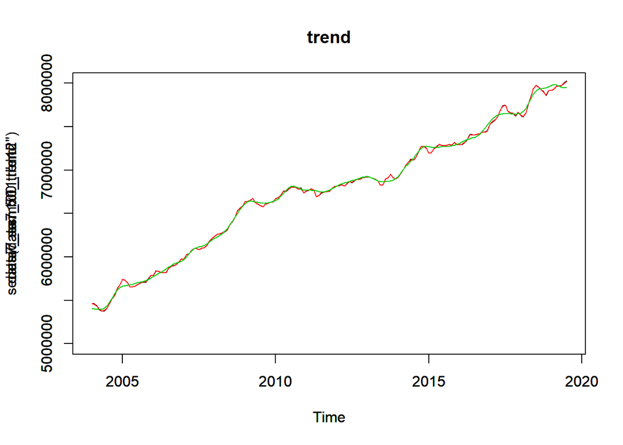

```r
plot(data7_ssm100_trend,ylim=c(5*10^6,8*10^6))
par(new=TRUE)
plot(data7_ssm50_trend,ylim=c(5*10^6,8*10^6),col=2)
par(new=TRUE)
plot(series(data7_x11, 'd12'),ylim=c(5*10^6,8*10^6),col=3)
title('trend')
```

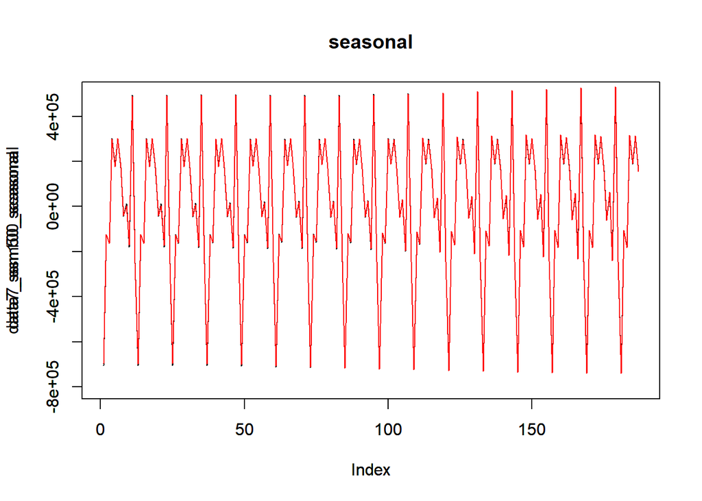

```r
plot(data7_ssm100_seasonal,type='l',ylim=c(-8*10^5, 5*10^5))
par(new=TRUE)
plot(data7_ssm50_seasonal,type='l',ylim=c(-8*10^5, 5*10^5),col=2)
title('seasonal')
```

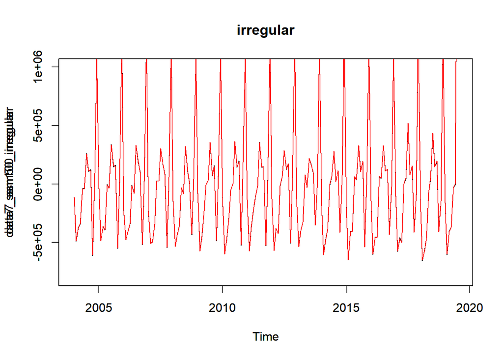

```r
plot(data7_ssm100_irregular,type='l',ylim=c(-8*10^5, 10^6))
par(new=TRUE)
plot(data7_ssm50_irregular,type='l',ylim=c(-8*10^5, 10^6),col=2)
title('irregular')
```

Remember our final goal is to come up with a good loss function!!!!!(**Update: this loss function seems to be sensible later**)

Obviously, the result from 1, 0.3, 1(0.3 is chosen randomly) is much better than those from 50501 and 1001001.

Let’s see the exhaustion result of the preprocessing data:

```r
data5_exhaustion <- exhaustion1(series(data5_x11, 'b1'))
data5_exhaustion[which.min(data5_exhaustion$difference),]
```

```
##           variance.1 variance.2 variance.3 difference
## sigma.402          9          3          1 6604997322
```

```r
data7_exhaustion <- exhaustion1(series(data7_x11,'b1'))
data7_exhaustion[which.min(data7_exhaustion$difference),]
```

```
##           variance.1 variance.2 variance.3   difference
## sigma.452         10          3          1 1.812751e+13
```

- - … well, when I use the preprocessed data, the result seems to be good then, which is what I want to see but also don’t want to see.

Let’s see the visualization results from them:

```r
data5_ssmmexhaustion <- SSModel(series(data5_x11,'b1') ~ SSMtrend(1, Q=list(3)) +
                     SSMseasonal(12, sea.type = 'dummy', Q = 1),
                   H = 9)
data5_ssmexhaustion <- KFS(data5_ssmmexhaustion)


data7_ssmmexhaustion <- SSModel(series(data7_x11,'b1') ~ SSMtrend(1, Q=list(3)) +
                     SSMseasonal(12, sea.type = 'dummy', Q = 1),
                   H = 10)
data7_ssmexhaustion <- KFS(data7_ssmmexhaustion)


data5_ssmexhaustion_trend <- coef(data5_ssmexhaustion, states = 'trend')
data5_ssmexhaustion_seasonal <- -rowSums(coef(data5_ssmexhaustion, states='seasonal'))
data5_ssmexhaustion_irregular <- series(data5_x11,'b1') - data5_ssmexhaustion_trend[-1] - data5_ssmexhaustion_seasonal[-length(data)]
data7_ssmexhaustion_trend <- coef(data7_ssmexhaustion, states = 'trend')
data7_ssmexhaustion_seasonal <- -rowSums(coef(data7_ssmexhaustion, states='seasonal'))
data7_ssmexhaustion_irregular <- series(data7_x11,'b1') - data7_ssmexhaustion_trend[-1] - data7_ssmexhaustion_seasonal[-length(data)]
```

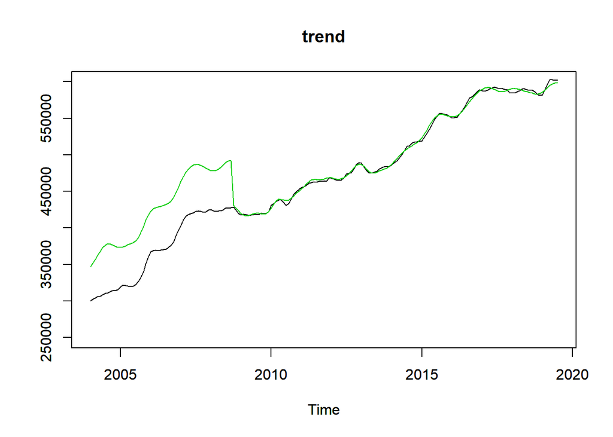

```r
plot(data5_ssmexhaustion_trend,ylim=c(2.5*10^5, 6*10^5),ylab='')
par(new=TRUE)
plot(series(data5_x11, 'd12'),ylim=c(2.5*10^5, 6*10^5),ylab='',col=3)
title('trend')
```

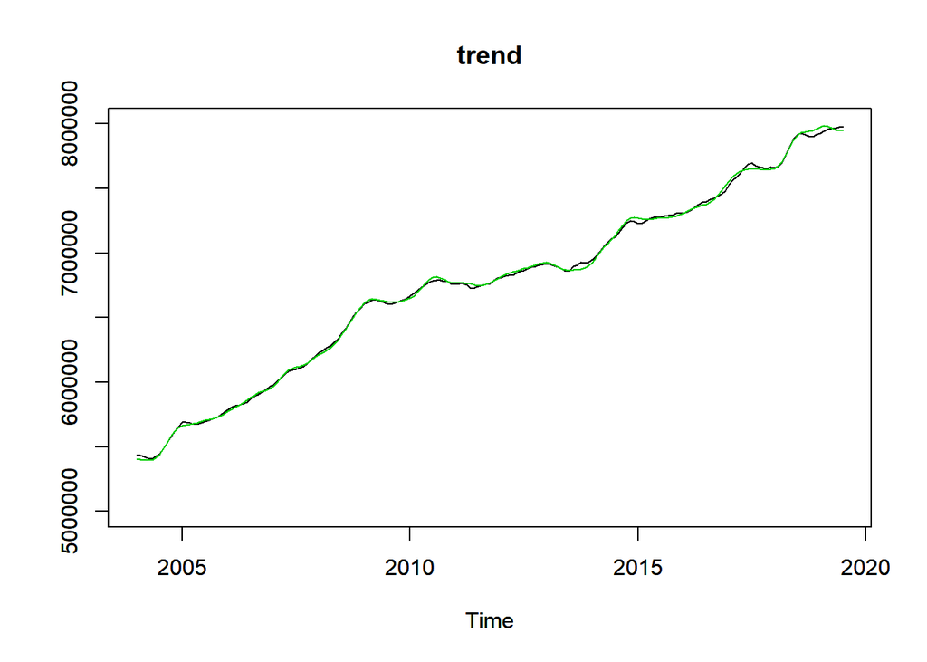

```r
plot(data7_ssmexhaustion_trend,ylim=c(5*10^6,8*10^6),ylab='')
par(new=TRUE)
plot(series(data7_x11, 'd12'),ylim=c(5*10^6,8*10^6),ylab='',col=3)
title('trend')
```

```r
# plot(data7_ssmexhaustion_seasonal,type='l',ylim=c(-8*10^5, 5*10^5))
# par(new=TRUE)
# plot(data7_ssmexhaustion_seasonal,type='l',ylim=c(-8*10^5, 5*10^5),col=2)
# title('seasonal')
#
# plot(data7_ssmexhaustion_irregular,type='l',ylim=c(-8*10^5, 10^6))
# par(new=TRUE)
# plot(data7_ssmexhaustion_irregular,type='l',ylim=c(-8*10^5, 10^6),col=2)
# title('irregular')
```

For data5, there is a huge change around 2009. hehehehehehehe,心里一句妈卖批不值当讲不当讲。

**We need to fix this.**

Anyway, let’s see the difference between data5&7 and the corresponding preprocessed:

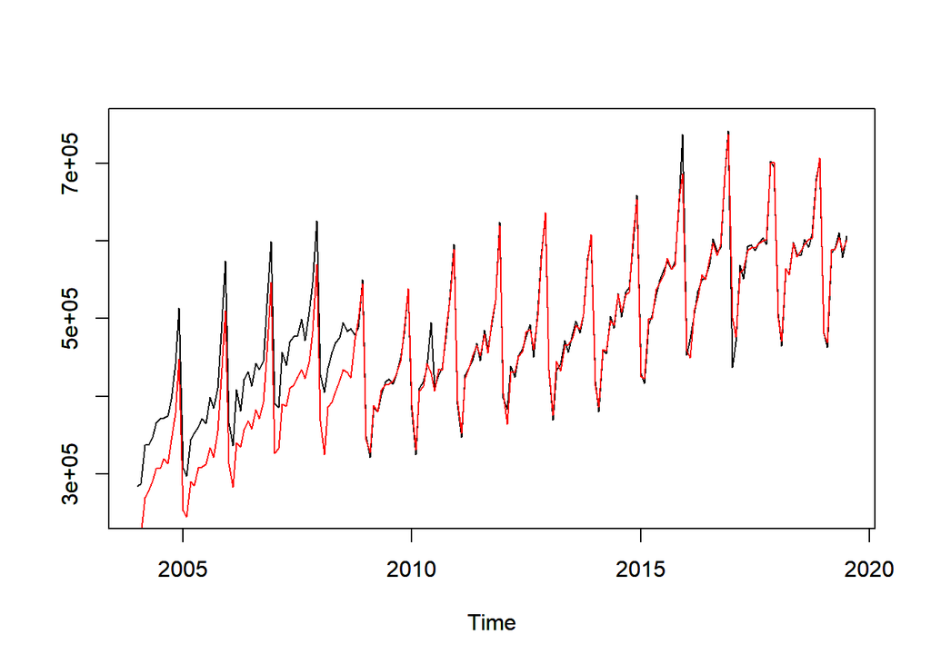

```r
plot(data5,ylab='', ylim=c(2.5*10^5, 7.5*10^5))
par(new=TRUE)
plot(series(data5_x11, 'b1'), ylab='', ylim=c(2.5*10^5, 7.5*10^5),col=2)
```

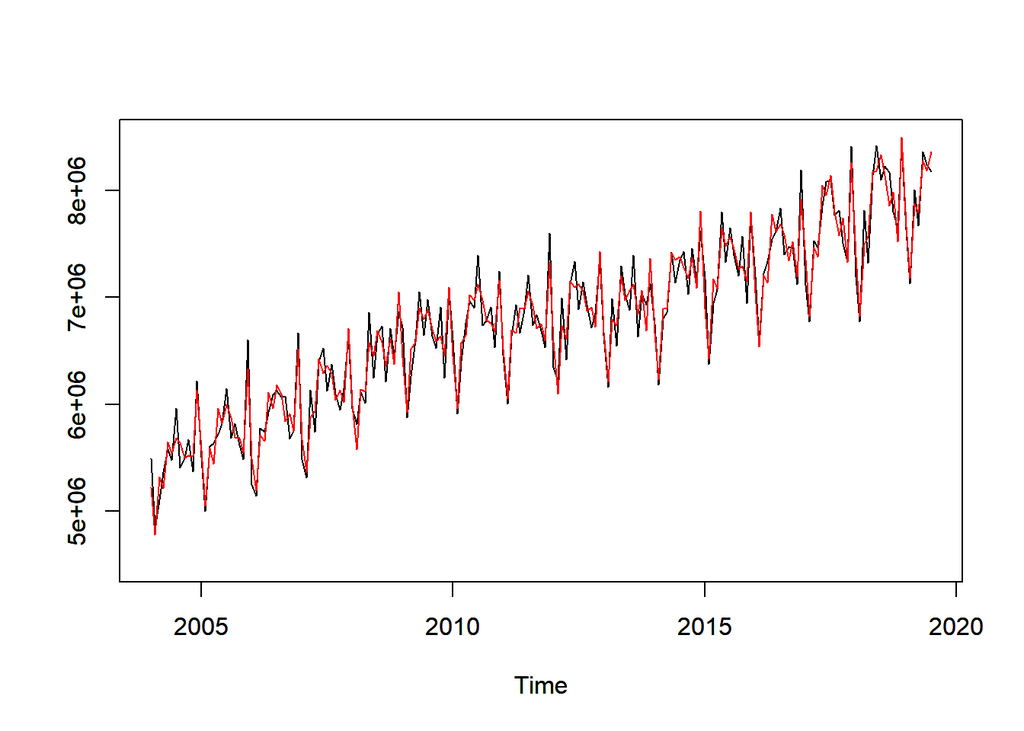

```r
plot(data7,ylab='', ylim=c(4.5*10^6, 8.5*10^6))
par(new=TRUE)
plot(series(data7_x11, 'b1'),ylab='', ylim=c(4.5*10^6, 8.5*10^6), col=2)
```

The first pic above shows why the trend from ssm is different from that from tramo-seats/x11, cause we make some adjustment at the first part(about 5 years). But in traditional methods, they put this back after some operation.

This part is to see which parameter leads to this change:

```r
summary(data5_x11)
```

```
##
## Call:
## seas(x = data5, x11 = "")
##
## Coefficients:
##                     Estimate Std. Error z value Pr(>|z|)
## Leap Year          2.455e+04  6.281e+03   3.909 9.28e-05 ***
## Mon                5.894e+03  2.011e+03   2.931  0.00338 **
## Tue               -2.171e+03  2.043e+03  -1.062  0.28809
## Wed                1.730e+03  2.021e+03   0.856  0.39193
## Thu                1.108e+03  2.001e+03   0.554  0.57957
## Fri                3.158e+03  1.992e+03   1.585  0.11301
## Sat                4.174e+02  2.009e+03   0.208  0.83540
## Easter[8]         -8.727e+03  3.762e+03  -2.320  0.02037 *
## LS2008.Oct        -5.917e+04  1.131e+04  -5.233 1.66e-07 ***
## AO2010.Jun         6.587e+04  1.174e+04   5.610 2.03e-08 ***
## AO2015.Dec         4.973e+04  1.178e+04   4.220 2.44e-05 ***
## AO2017.Jan        -5.726e+04  1.180e+04  -4.852 1.22e-06 ***
## MA-Nonseasonal-01  5.218e-01  6.367e-02   8.195 2.50e-16 ***
## MA-Seasonal-12     5.595e-01  6.832e-02   8.189 2.63e-16 ***
## ---
## Signif. codes:  0 '***' 0.001 '**' 0.01 '*' 0.05 '.' 0.1 ' ' 1
##
## X11 adj.  ARIMA: (0 1 1)(0 1 1)  Obs.: 187  Transform: none
## AICc:  3874, BIC:  3918  QS (no seasonality in final): 3.75
## Box-Ljung (no autocorr.):  20.4   Shapiro (normality): 0.9849 *
```

I think the shift should be due to **LS2008.Oct** in the model.

Again 我可能还是要先忽略这个东西才能继续做下去。F**k。就很烦。但是问题很多我又不能都解决，这也许是做研究经常遇到的问题吧。一次一个，做完一个也就很棒了，然后转而继续研究之前发现却没有解决的问题。那么现在，如何摆脱preprocess的困扰呢？我可以在preprocessed data上用x11/tramo-seats！！！！是不是很聪明？好像很显然…

Let’s compare the x11 results from the preprocessed data:(this will **COVER** the model we defined before)

```r
data5 <- series(data5_x11, 'b1')
data5_x11 <- seas(data5, x11='')
summary(data5_x11)
```

```
##
## Call:
## seas(x = data5, x11 = "")
##
## Coefficients:
##                   Estimate Std. Error z value Pr(>|z|)
## MA-Nonseasonal-01  0.52176    0.06367   8.195 2.51e-16 ***
## MA-Seasonal-12     0.55947    0.06832   8.189 2.63e-16 ***
## ---
## Signif. codes:  0 '***' 0.001 '**' 0.01 '*' 0.05 '.' 0.1 ' ' 1
##
## X11 adj.  ARIMA: (0 1 1)(0 1 1)  Obs.: 187  Transform: none
## AICc:  3847, BIC:  3856  QS (no seasonality in final):    0
## Box-Ljung (no autocorr.):  20.4   Shapiro (normality): 0.9849 *
```

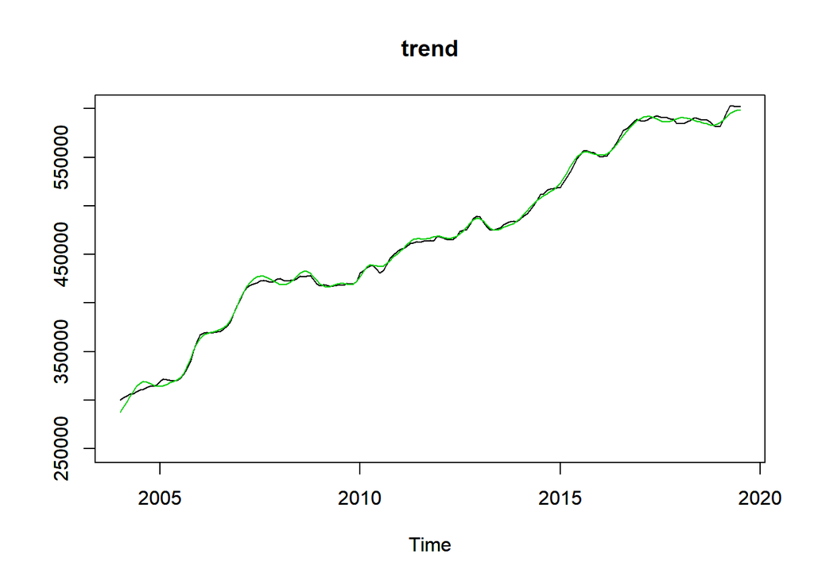

```r
plot(data5_ssmexhaustion_trend,ylim=c(2.5*10^5, 6*10^5),ylab='')
par(new=TRUE)
plot(series(data5_x11, 'd12'),ylim=c(2.5*10^5, 6*10^5),ylab='',col=3)
title('trend')
```

我又要重复一些东西了hhhhhh。既然我们这里用预处理后的数据做model，那么exhaustion part need to be modified then.

不对！刚刚我的exhaustion用的就是preprocessed data 。哎，我怎么如此优秀。

**TIAN XIU!**

[figure not shown]

Let’s do the same thing for the other dataset.

```r
data1 <- series(data1_x11, 'b1')
data2 <- series(data2_x11, 'b1')
data3 <- series(data3_x11, 'b1')
data4 <- series(data4_x11, 'b1')
data6 <- series(data6_x11, 'b1')
data7 <- series(data7_x11, 'b1')
data8 <- series(data8_x11, 'b1')
data9 <- series(data9_x11, 'b1')
data10 <- series(data10_x11, 'b1')

data1_x11 <- seas(data1, x11='')
data2_x11 <- seas(data2, x11='')
data3_x11 <- seas(data3, x11='')
data4_x11 <- seas(data4, x11='')
data6_x11 <- seas(data6, x11='')
data7_x11 <- seas(data7, x11='')
data8_x11 <- seas(data8, x11='')
data9_x11 <- seas(data9, x11='')
data10_x11 <- seas(data10, x11='')
```

或许我可以用与处理后的数据试试logposterior？

```r
data5_postmatrix <- logposterior_matrix(series(data5_x11,'b1'),10^7,10^7)
data5_postmatrix[which.max(data5_postmatrix$logposterior), ]
```

```
##            variance.1 variance.2 variance.3 logposterior
## sigma.9999         10         10          1   -798765531
```

```r
data7_postmatrix <- logposterior_matrix(series(data7_x11,'b1'),10^11,10^11)
data7_postmatrix[which.max(data7_postmatrix$logposterior), ]
```

```
##           variance.1 variance.2 variance.3  logposterior
## sigma.907          1        0.8          1 -357972305019
```

It is running now, so i can’t run anything for now. Just write for killing the time: if I can have the map value that I want, then what should I do next?

But remember our data: **(i)** doesn’t need to be transformed; **(ii)** need to be preprocessed before analyzing.

Let’s try a babay(stupid) model for searching a general choice of c1 and c2 in prior 1:

```r
logposterior_matrix <- function(data, c1, c2){
  LP <- c()
  index <- c()
   for (i in 1:20) {
     for (j in 1:20) {

         ssmm <- SSModel(data ~ SSMtrend(1, Q=list(j)) +
                   SSMseasonal(12, sea.type = 'dummy', Q = 1),
                 H = i)
         ssm <- KFS(ssmm)

         ssm_trend <- coef(ssm, states = 'trend')
         ssm_seasonal <- -rowSums(coef(ssm, states='seasonal'))
  #      ssm_seasadj <- data[-1] - ssm_seasonal[-length(data)] # length is shorter
         sigma <- c(i, j, 1)

         lp <- loglikelihood(data, ssm_trend, ssm_seasonal, sigma) + logprior1(sigma, c1, c2)
         LP <- c(LP, lp)
         index <- rbind(index, sigma)

      }
   }
  df <- data.frame(variance=index, logposterior=LP)
  return(df)
}
```

```r
Prior1_gridsearch <- function(dataset1,dataset2,dataset3){
  Error <- c()
  index <- c()
  dataset1_x11 <- seas(dataset1,x11='')
  dataset2_x11 <- seas(dataset2,x11='')
  dataset3_x11 <- seas(dataset3,x11='')

  for (i in 1:10) {
    for (j in 1:10) {

      dataset1_postmatrix <- logposterior_matrix(dataset1,10^(i-1),10^(j-1))
      map1 <- as.numeric(dataset1_postmatrix[which.max(dataset1_postmatrix$logposterior),][-4])


      ssmm1 <- SSModel(dataset1 ~ SSMtrend(1, Q=list(map1[2])) +
                     SSMseasonal(12, sea.type = 'dummy', Q = 1),
                   H = map1[1])
      ssm1 <- KFS(ssmm1)
      dif1 <- Dif1(dataset1_x11,ssm1,dataset1,map1)


      dataset2_postmatrix <- logposterior_matrix(dataset2,10^(i-1),10^(j-1))
      map2 <- as.numeric(dataset2_postmatrix[which.max(dataset2_postmatrix$logposterior),][-4])

      ssmm2 <- SSModel(dataset2 ~ SSMtrend(1, Q=list(map2[2])) +
                     SSMseasonal(12, sea.type = 'dummy', Q = 1),
                   H = map2[1])
      ssm2 <- KFS(ssmm2)
      dif2 <- Dif1(dataset2_x11,ssm2,dataset2,map2)


      dataset3_postmatrix <- logposterior_matrix(dataset3,10^(i-1),10^(j-1))
      map3 <- as.numeric(dataset3_postmatrix[which.max(dataset3_postmatrix$logposterior),][-4])

      ssmm3 <- SSModel(dataset3 ~ SSMtrend(1, Q=list(map3[2])) +
                     SSMseasonal(12, sea.type = 'dummy', Q = 1),
                   H = map3[1])
      ssm3 <- KFS(ssmm3)
      dif3 <- Dif1(dataset3_x11,ssm3,dataset3,map3)

      error <- dif1+dif2+dif3
      Error <- c(Error, error)
      index <- rbind(index, c(10^(i-1),10^(j-1)))
    }
  }
  return(data.frame(c1=index[,1],c2=index[,2],Error=Error))
}
```

```r
c1c2_gridsearch <- Prior1_gridsearch(data5,data7,unemp)
c1c2_gridsearch[which.min(c1c2_gridsearch$Error),]
```

```
##       c1    c2       Error
## 90 1e+08 1e+09 1.81426e+13
```

Again I am waiting for the above code to finish, so just write something general: the final goal that what I want is an algorithm which combines KFAS and seasonal packages. My algorithm will only require the dataset ideally and then output the results based on state-space model.

OK I get the result now! Before doing any analysis, let’s see the corresponding map value for these three datasets:

```r
data5_postmatrix <- logposterior_matrix(data5,10^8,10^9)
data7_postmatrix <- logposterior_matrix(data7,10^8,10^9)
unemp_postmatrix <- logposterior_matrix(unemp,10^8,10^9)

data5_postmatrix[which.max(data5_postmatrix$logposterior),]
```

```
##           variance.1 variance.2 variance.3 logposterior
## sigma.140          8          1          1  -3379077516
```

```r
data7_postmatrix[which.max(data7_postmatrix$logposterior),]
```

```
##           variance.1 variance.2 variance.3 logposterior
## sigma.386         20          7          1 -24058666411
```

```r
unemp_postmatrix[which.max(unemp_postmatrix$logposterior),]
```

```
##       variance.1 variance.2 variance.3 logposterior
## sigma          1          1          1  -1104858499
```

Of course I know these result is not good, cause the data7 plays a more important role in our error sum due to its magnitude. And since our unemp data is much smaller, the final MAP value is 111, whose best value from exhaustion is 751 if you guys remember.(I don’t know who I am talking with, just for fun:).)

So just like what Aaron and I have talked last week, if we want to make a more brilliant decision, we need to look at our data, which means the choice of c1 and c2(take prior1 as an example) should be some function of the data.

**Leave it here for a moment!**

Let’s look at those cases which need to be transformed at first then I will go home.

**Review**

```
Dif2 <- function(x11, ssm, data, sigma){

  x11_trend <- series(x11, 'd12')
  x11_seasonal <- series(x11, 'd10')
  x11_irregular <- series(x11, 'd13')

  ssm_trend <- exp(coef(ssm, states = 'trend'))
  ssm_seasonal <- exp(-rowSums(coef(ssm, states='seasonal')))
  ssm_irregular <- data[-1]/(ssm_trend[-1]*ssm_seasonal[-length(data)])

  D <-  sum((x11_irregular[-1]-ssm_irregular)^2)/sigma[1] +
    sum((x11_trend-ssm_trend)^2)/sigma[2] +
    sum((x11_seasonal[-1]-ssm_seasonal[-length(data)])^2)/sigma[3]

  return(D)
}

exhaustion2 <- function(data){

  Difference <- c()
  index <- c()

  x11 <- seas(data, x11='')
   for (i in 1:50) {
     for (j in 1:50) {

           ssmm <- SSModel(log(data) ~ SSMtrend(1, Q=list(j*0.02)) +
                     SSMseasonal(12, sea.type = 'dummy', Q = 1),
                   H = i*0.02)
           ssm <- KFS(ssmm)

           sigma <- c(i*0.02, j*0.02, 1)

           dif <- Dif2(x11, ssm, data, sigma)

           Difference <- c(Difference, dif)

           index <- rbind(index, sigma)
      }
   }

  df <- data.frame(variance=index, difference = Difference)
  return(df)
}
```

Let’s see the results from exhaustion:

```r
data1_exhaustion <- exhaustion2(data1)
data1_exhaustion[which.min(data1_exhaustion$difference),]
```

```
##            variance.1 variance.2 variance.3   difference
## sigma.2499          1          1          1 8.042067e+12
```

```r
data2_exhaustion <- exhaustion2(data2)
data2_exhaustion[which.max(data2_exhaustion$difference),]
```

```
##            variance.1 variance.2 variance.3   difference
## sigma.2450          1       0.02          1 2.808544e+14
```

what if we change the setting of variances to 1:50?

```r
exhaustion2 <- function(data){

  Difference <- c()
  index <- c()

  x11 <- seas(data, x11='')
   for (i in 1:50) {
     for (j in 1:50) {

           ssmm <- SSModel(log(data) ~ SSMtrend(1, Q=list(j)) +
                     SSMseasonal(12, sea.type = 'dummy', Q = 1),
                   H = i)
           ssm <- KFS(ssmm)

           sigma <- c(i, j, 1)

           dif <- Dif2(x11, ssm, data, sigma)

           Difference <- c(Difference, dif)

           index <- rbind(index, sigma)
      }
   }

  df <- data.frame(variance=index, difference = Difference)
  return(df)
}
```

```r
data1_exhaustion <- exhaustion2(data1)
data1_exhaustion[which.min(data1_exhaustion$difference),]
```

```
##            variance.1 variance.2 variance.3   difference
## sigma.2499         50         50          1 282650701006
```

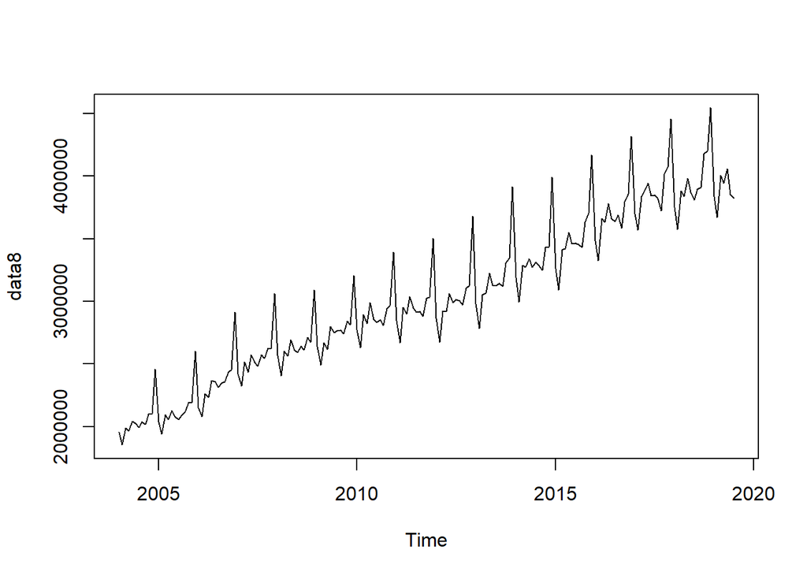

```r
plot(data8)
```

```r
summary(data8_x11)
```

```
##
## Call:
## seas(x = data8, x11 = "")
##
## Coefficients:
##                   Estimate Std. Error z value Pr(>|z|)
## MA-Nonseasonal-01  0.15316    0.07481   2.047  0.04063 *
## MA-Seasonal-12     0.26869    0.07670   3.503  0.00046 ***
## ---
## Signif. codes:  0 '***' 0.001 '**' 0.01 '*' 0.05 '.' 0.1 ' ' 1
##
## X11 adj.  ARIMA: (0 1 1)(0 1 1)  Obs.: 187  Transform: log
## AICc:  4169, BIC:  4178  QS (no seasonality in final):13.31 **
## Box-Ljung (no autocorr.): 16.04   Shapiro (normality): 0.9899
```

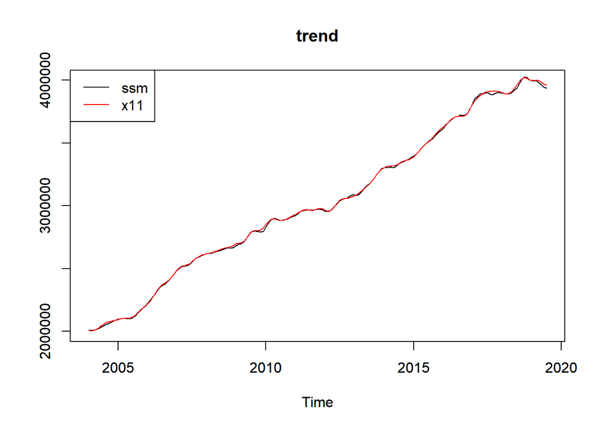

```r
data8_ssmm <- SSModel(log(data8) ~ SSMtrend(1, Q=list(1)) +
                     SSMseasonal(12, sea.type = 'dummy', Q = 1),
                   H = 1)
data8_ssm <- KFS(data8_ssmm)

data8_ssm_trend <- exp(coef(data8_ssm, states = 'trend'))
data8_ssm_seasonal <- exp(-rowSums(coef(data8_ssm, states='seasonal')))
data8_ssm_irregular <- data8[-1]/(data8_ssm_trend[-1]*data8_ssm_seasonal[-length(data8)])

plot(data8_ssm_trend,type='l',ylim=c(2*10^6,4*10^6),ylab='')
par(new=TRUE)
plot(series(data8_x11,'d12'),ylim=c(2*10^6,4*10^6),ylab='',col=2)
title(main='trend')
legend('topleft', c('ssm','x11'),col=c(1,2),lty=1)
```

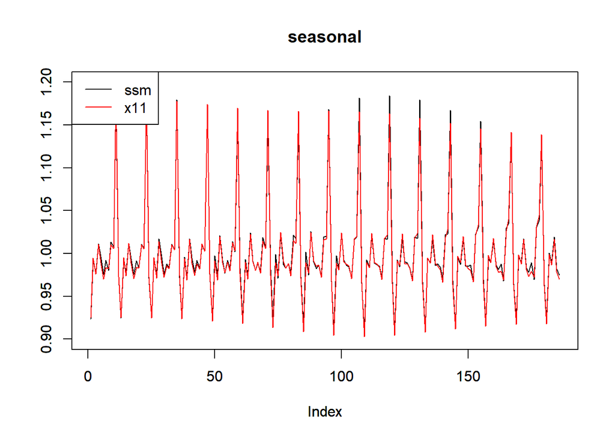

```r
plot(data8_ssm_seasonal[-length(data8)],type='l',ylab='',ylim=c(0.9,1.2))
par(new=TRUE)
plot(series(data8_x11,'d10')[-1],type='l',ylab='',ylim=c(0.9,1.2),col=2)
title('seasonal')
legend('topleft', c('ssm','x11'),col=c(1,2),lty=1)
```

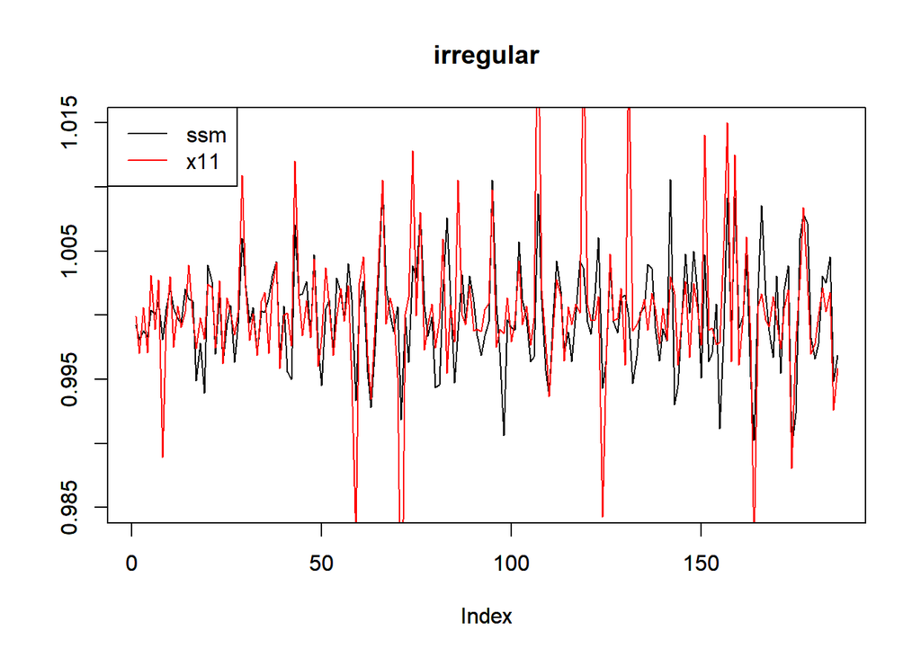

```r
plot(data8_ssm_irregular,type='l',ylim=c(0.985,1.015),ylab='')
par(new=TRUE)
plot(series(data8_x11,'d13')[-1],type='l',ylim=c(0.985,1.015),ylab='',col=2,)
title('irregular')
legend('topleft', c('ssm','x11'),col=c(1,2),lty=1)
```

看着也没啥啊！那为啥loss就是inf了？trend很接近彼此的啊，主要有差别的是irregular，但是这个magnitude很小啊！我算算loss是多少：

```r
Dif2(data8_x11,data8_ssm,data8,c(1,1,1))
```

```
## [1] 12823024389
```

wtf :) … I forgot to update my loss function !!!! I guess the above code should make sense now. But I want to check whether the multiplication of trend, seasonal and irregular is equal to data8 itself:

```r
data8_prod <- series(data8_x11,'d12') *series(data8_x11,'d10')*series(data8_x11,'d13')
sum(data8-data8_prod)
```

```
## [1] 1.236331e-07
```

Well they are equal to each other!